# GES 001 演習2

H. Suzuki

2023-12-20

## 第2週

12/14(TH) 所得と富の不平等の現状１

所得と富の不平等の現状２

講義では、第2週、第3週とWorld Inequality report 2022を使って、所得と富の不平等について議論します。

12/19(TU) Rでデータサイエンス2：人口の少子高齢化 [[Main](https://ds-sl.github.io/intro2r/ges001/ges001-main.nb.html)]・[授業]

**People- Population dynamics**

総人口 Population, total：SP.POP.TOTL [[Link](https://data.worldbank.org/indicator/SP.POP.TOTL)]

出生率（千人）Birth rate, crude (per 1,000 people)：SP.DYN.CBRT.IN [[Link](https://data.worldbank.org/indicator/SP.DYN.CBRT.IN)]

死亡率（千人）Death rate, crude (per 1,000 people)：SP.DYN.CDRT.IN [[Link](https://data.worldbank.org/indicator/SP.DYN.CDRT.IN)]

若年労働人口率 Age dependency ratio, young (% of working-age population)：SP.POP.DPND.YG [[Link](https://data.worldbank.org/indicator/SP.POP.DPND.YG)]

高齢者労働人口率 Age dependency ratio, old (% of working-age population)：SP.POP.DPND.OL [[Link to Metadata](https://databank.worldbank.org/metadataglossary/health-nutrition-and-population-statistics/series/SP.POP.DPND.OL)]

## 内容

- Package：tidyverse, WDI
- データの取得
- 特定の行の取得：filter
- 折れ線グラフ
- 散布図

### トピック：人口の少子高齢化

```r
library(tidyverse)
library(WDI)
```

```r
df_pop <- WDI(indicator = c(pop = "SP.POP.TOTL",
                            birth_rate = "SP.DYN.CBRT.IN",
                            death_rate = "SP.DYN.CDRT.IN",
                            young = "SP.POP.DPND.YG",
                            old = "SP.POP.DPND.OL"))
```

```r
write_csv(df_pop, "data/pop.csv")
```

```r
df_pop <- read_csv("data/pop.csv")
```

```r
df_pop
```

| country | iso2c | iso3c | year | pop | birth_rate | death_rate | young | old |
| --- | --- | --- | --- | --- | --- | --- | --- | --- |
| Afghanistan | AF | AFG | 1960 | 8622466 | 50.34000 | 31.921000 | 74.95021 | 5.100901 |
| Afghanistan | AF | AFG | 1961 | 8790140 | 50.44300 | 31.349000 | 75.14425 | 5.078088 |
| Afghanistan | AF | AFG | 1962 | 8969047 | 50.57000 | 30.845000 | 75.35238 | 5.049558 |
| Afghanistan | AF | AFG | 1963 | 9157465 | 50.70300 | 30.359000 | 75.69330 | 5.022020 |
| Afghanistan | AF | AFG | 1964 | 9355514 | 50.83100 | 29.867000 | 76.21984 | 4.999719 |
| Afghanistan | AF | AFG | 1965 | 9565147 | 50.87200 | 29.389000 | 77.00953 | 4.985287 |
| Afghanistan | AF | AFG | 1966 | 9783147 | 50.98600 | 28.872000 | 77.97556 | 4.979162 |
| Afghanistan | AF | AFG | 1967 | 10010030 | 51.08100 | 28.396000 | 78.93114 | 4.976931 |
| Afghanistan | AF | AFG | 1968 | 10247780 | 51.14800 | 27.895000 | 79.86815 | 4.976000 |
| Afghanistan | AF | AFG | 1969 | 10494489 | 51.19500 | 27.398000 | 80.78632 | 4.974508 |

[output cut: 990 more lines]

#### それぞれ十分なデータがあるかチェック

```r
df_pop_long <- df_pop |>
  pivot_longer(5:9, names_to = "name", values_to = "value")
```

```r
df_pop_long |>
  group_by(year, name) |> drop_na(value) |>
  summarize(num = n()) |> arrange(desc(year))
```

| year | name | num |
| --- | --- | --- |
| 2022 | old | 265 |
| 2022 | pop | 265 |
| 2022 | young | 265 |
| 2021 | birth_rate | 261 |
| 2021 | death_rate | 261 |
| 2021 | old | 265 |
| 2021 | pop | 265 |
| 2021 | young | 265 |
| 2020 | birth_rate | 262 |
| 2020 | death_rate | 262 |

[output cut: 303 more lines]

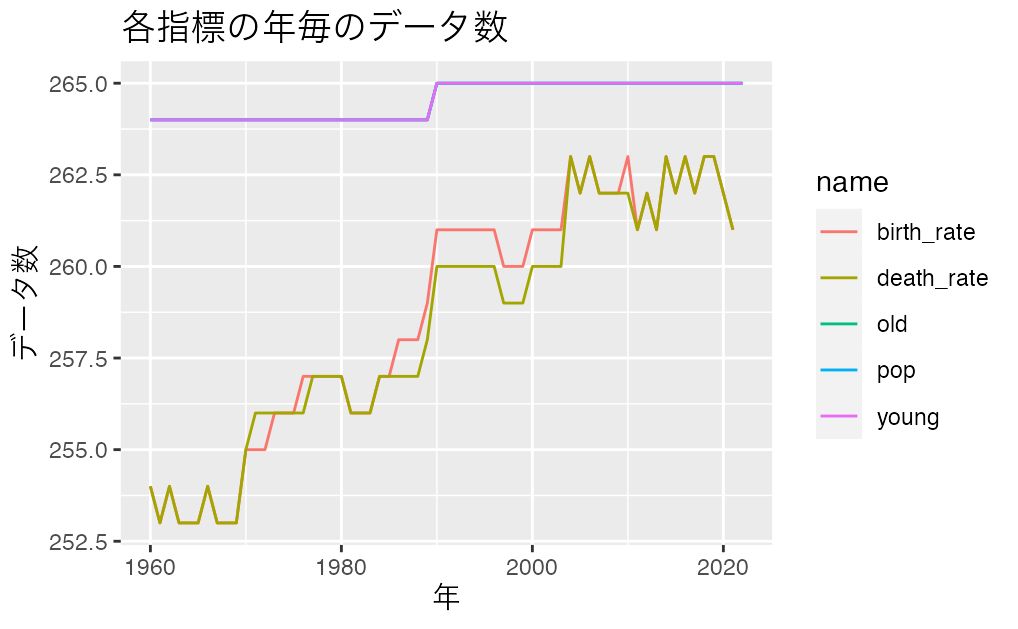

```r
df_pop_long |>
  group_by(year, name) |> drop_na(value) |>
  summarize(num = n()) |>
  ggplot(aes(year, num, col = name)) + geom_line() +
  labs(title = "各指標の年毎のデータ数", y = "データ数", x = "年")
```

253から265の国・地域のデータがあり、問題なし

```r
df_pop_extra <- WDI(indicator = c(pop = "SP.POP.TOTL",
                            birth_rate = "SP.DYN.CBRT.IN",
                            death_rate = "SP.DYN.CDRT.IN",
                            young = "SP.POP.DPND.YG",
                            old = "SP.POP.DPND.OL"), extra = TRUE)
```

```r
write_csv(df_pop_extra, "data/pop_extra.csv")
```

```r
df_pop_extra <- read_csv("data/pop_extra.csv")
```

```r
str(df_pop_extra)
```

[output not shown]

```r
glimpse(df_pop_extra)
```

[output not shown]

いくつかの文字ベクトルの内容確認

```r
df_pop_extra |> select(region, income, lending, status) |> lapply(unique)
```

[output not shown]

```r
REGION <- df_pop_extra |> filter(region %in% c("Aggregates", NA)) |> distinct(iso2c) |> pull()
length(REGION)
```

[output not shown]